# Data Distributions

Anoob Prakash

3 October 2018

#### Long and wide data formats

Try converting the iris data set into the long format, with a column called “trait” to indicate sepal and petal length and width.

Once you have converted to the long format, calculate the average for each combination of species and trait.

```r
library(tidyverse)
longDat <- iris %>%
  gather(Sepal.Length:Petal.Width, key = "trait", value = "value") %>%
  arrange(Species)

head(longDat)
```

```
##   Species        trait value
## 1  setosa Sepal.Length   5.1
## 2  setosa Sepal.Length   4.9
## 3  setosa Sepal.Length   4.7
## 4  setosa Sepal.Length   4.6
## 5  setosa Sepal.Length   5.0
## 6  setosa Sepal.Length   5.4
```

```r
SpsTrait <- longDat %>%
  group_by(Species,trait) %>%
  summarize(meanValues = mean(value)) %>%
  arrange(Species,trait)
print(SpsTrait)
```

```
## # A tibble: 12 x 3
## # Groups:   Species [3]
##    Species    trait        meanValues
##    <fct>      <chr>             <dbl>
##  1 setosa     Petal.Length      1.46
##  2 setosa     Petal.Width       0.246
##  3 setosa     Sepal.Length      5.01
##  4 setosa     Sepal.Width       3.43
##  5 versicolor Petal.Length      4.26
##  6 versicolor Petal.Width       1.33
##  7 versicolor Sepal.Length      5.94
##  8 versicolor Sepal.Width       2.77
##  9 virginica  Petal.Length      5.55
## 10 virginica  Petal.Width       2.03
## 11 virginica  Sepal.Length      6.59
## 12 virginica  Sepal.Width       2.97
```

#### Simulating and Fitting Data Distributions

The data used for fitting the distribution is from a study conducted by me on `moist deciduous trees` under particulate pollution of Western Ghats of Kerala, India. Out of the several variable studied, I am using the `relative water content` (RWC) as the variable for testing the effects of particulate pollution. :

```r
z <- read.table("MyDataFile.csv",header=TRUE,sep=",", stringsAsFactors=FALSE) # myVar is the RWC for the species studied
str(z)
```

```
## 'data.frame':    30 obs. of  2 variables:
##  $ ID   : chr  "Tectona grandis" "Tectona grandis" "Tectona grandis" "Terminalia paniculata" ...
##  $ myVar: num  49.5 47.9 49.8 76.8 80.4 ...
```

```r
summary(z)
```

```
##       ID                myVar
##  Length:30          Min.   :38.02
##  Class :character   1st Qu.:55.31
##  Mode  :character   Median :75.19
##                     Mean   :70.72
##                     3rd Qu.:81.50
##                     Max.   :97.71
```

```r
print(z)
```

```
##                          ID    myVar
## 1           Tectona grandis 49.49000
## 2           Tectona grandis 47.94000
## 3           Tectona grandis 49.75000
## 4     Terminalia paniculata 76.85000
## 5     Terminalia paniculata 80.38000
## 6     Terminalia paniculata 78.52000
## 7              Bombax ceiba 79.58000
## 8              Bombax ceiba 78.46000
## 9              Bombax ceiba 76.07000
## 10         Butea monosperma 97.71000
## 11         Butea monosperma 93.14000
## 12         Butea monosperma 97.52000
## 13           Cassia fistula 73.58000
## 14           Cassia fistula 74.31000
```

[output cut: 16 more lines]

```r
library(ggplot2) # for graphics
library(MASS) # for maximum likelihood estimation
```

#### Plot histogram of data

Plot a histogram of the data using ggplot. Rescaling the y axis of the histogram from counts to density, so that the area under the histogram equals 1.0.

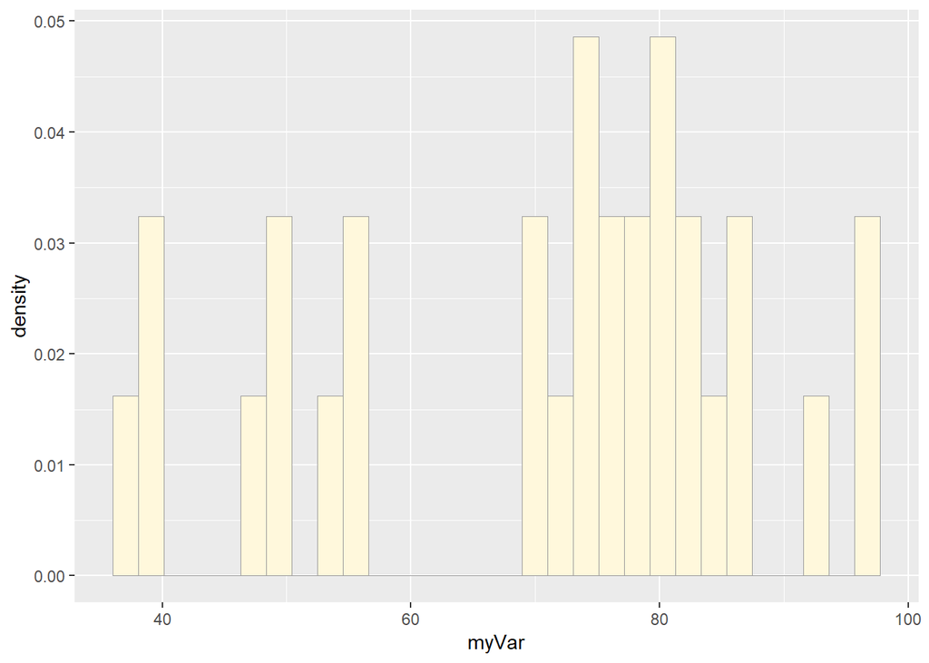

```r
p1 <- ggplot(data=z, aes(x=myVar, y=..density..)) +
  geom_histogram(color="grey60",fill="cornsilk",size=0.2)
print(p1)
```

#### Add empirical density curve

Modifying the code to add in a kernel density plot of the data. This is an empirical curve that is fitted to the data. It does not assume any particular probability distribution, but it smooths out the shape of the histogram:

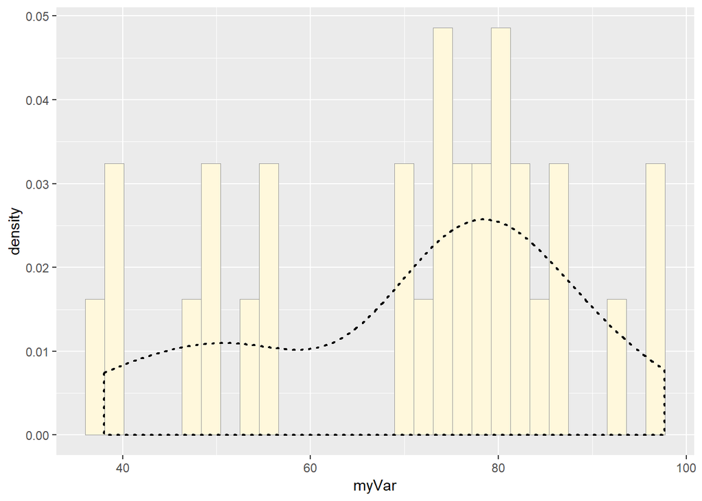

```r
p1 <-  p1 +  geom_density(linetype="dotted",size=0.75)
print(p1)
```

#### Get maximum likelihood parameters for normal

Fitting a normal distribution to the data and grabbing the maximum likelihood estimators of the two parameters of the normal, the mean and the variance:

```r
normPars <- fitdistr(z$myVar,"normal")
print(normPars)
```

```
##      mean         sd
##   70.715896   17.038861
##  ( 3.110856) ( 2.199708)
```

```r
str(normPars)
```

```
## List of 5
##  $ estimate: Named num [1:2] 70.7 17
##   ..- attr(*, "names")= chr [1:2] "mean" "sd"
##  $ sd      : Named num [1:2] 3.11 2.2
##   ..- attr(*, "names")= chr [1:2] "mean" "sd"
##  $ vcov    : num [1:2, 1:2] 9.68 0 0 4.84
##   ..- attr(*, "dimnames")=List of 2
##   .. ..$ : chr [1:2] "mean" "sd"
##   .. ..$ : chr [1:2] "mean" "sd"
##  $ n       : int 30
##  $ loglik  : num -128
##  - attr(*, "class")= chr "fitdistr"
```

```r
normPars$estimate["mean"] # note structure of getting a named attribute
```

```
##    mean
## 70.7159
```

#### Plot normal probability density

Let’s call the dnorm function inside ggplot’s stat_function to generate the probability density for the normal distribution.

Note: Read about stat_function in the help system to see how you can use this to add a smooth function to any ggplot. Note that we first get the maximum likelihood parameters for a normal distribution fitted to thse data by calling fitdistr. Then we pass those parameters (meanML and sdML to stat_function:

```r
meanML <- normPars$estimate["mean"]
sdML <- normPars$estimate["sd"]

xval <- seq(0,max(z$myVar),len=length(z$myVar))

 stat <- stat_function(aes(x = xval, y = ..y..), fun = dnorm, colour="red", n = length(z$myVar), args = list(mean = meanML, sd = sdML))
 p1 + stat
```

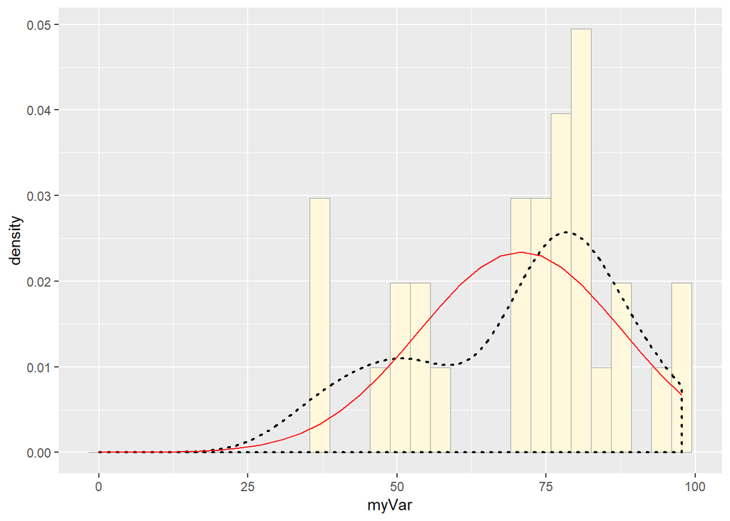

#### Plot exponential probability density

Now let’s use the same template and add in the curve for the exponential:

```r
expoPars <- fitdistr(z$myVar,"exponential")
rateML <- expoPars$estimate["rate"]

stat2 <- stat_function(aes(x = xval, y = ..y..), fun = dexp, colour="blue", n = length(z$myVar), args = list(rate=rateML))
 p1 + stat + stat2
```

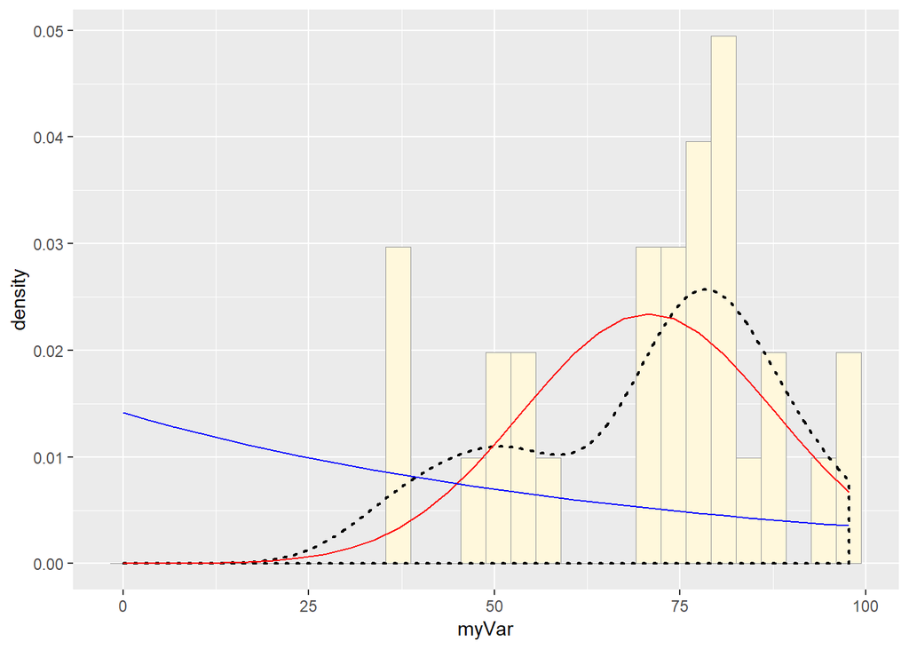

#### Plot uniform probability density

For the uniform, we don’t need to use fitdistr because the maximum likelihood estimators of the two parameters are just the minimum and the maximum of the data:

```r
stat3 <- stat_function(aes(x = xval, y = ..y..), fun = dunif, colour="darkgreen", n = length(z$myVar), args = list(min=min(z$myVar), max=max(z$myVar)))
 p1 + stat + stat2 + stat3
```

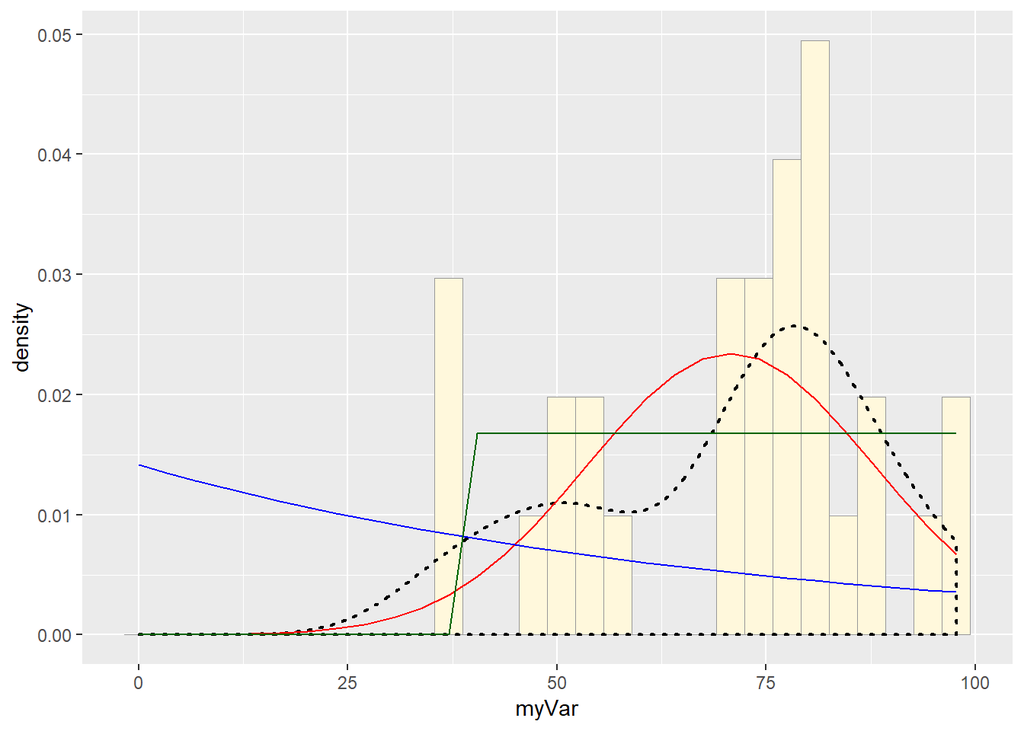

#### Plot gamma probability density

```r
gammaPars <- fitdistr(z$myVar,"gamma")
shapeML <- gammaPars$estimate["shape"]
rateML <- gammaPars$estimate["rate"]

stat4 <- stat_function(aes(x = xval, y = ..y..), fun = dgamma, colour="brown", n = length(z$myVar), args = list(shape=shapeML, rate=rateML))
 p1 + stat + stat2 + stat3 + stat4
```

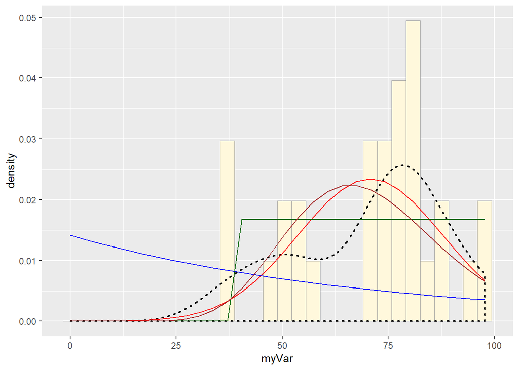

#### Plot beta probability density

This one has to be shown in its own plot because the raw data must be rescaled so they are between 0 and 1, and then they can be compared to the beta.

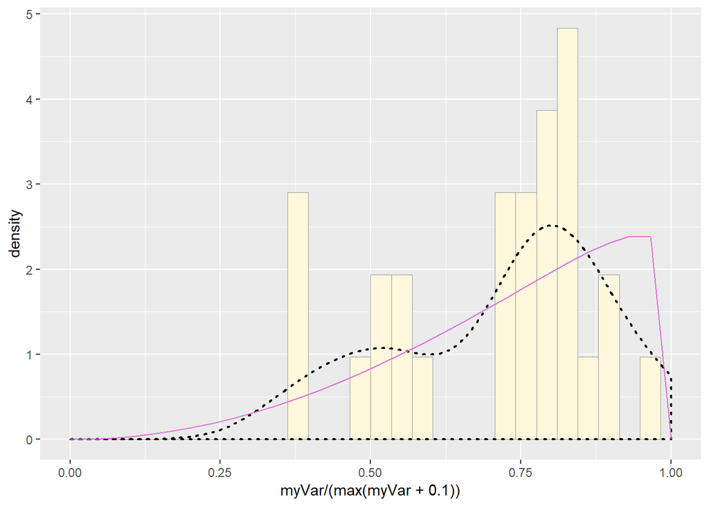

```r
pSpecial <- ggplot(data=z, aes(x=myVar/(max(myVar + 0.1)), y=..density..)) +
  geom_histogram(color="grey60",fill="cornsilk",size=0.2) +
  xlim(c(0,1)) +
  geom_density(size=0.75,linetype="dotted")

betaPars <- fitdistr(x=z$myVar/max(z$myVar + 0.1),start=list(shape1=1,shape2=2),"beta")
shape1ML <- betaPars$estimate["shape1"]
shape2ML <- betaPars$estimate["shape2"]

statSpecial <- stat_function(aes(x = xval, y = ..y..), fun = dbeta, colour="orchid", n = length(z$myVar), args = list(shape1=shape1ML,shape2=shape2ML))
pSpecial + statSpecial
```

From the above fittings, I found the `normal distribution to be a better fit` for the data on RWC for moist deciduous species under particulate pollution stress.